# DataAnalytics_A5_Shankar_Veludandi

2025-04-14

```r
library(dplyr)
```

```r
library(ggplot2)
library(corrplot)
data <- read.csv("C:/Users/Shankar Veludandi/Google Drive/ITWS_6600/A5/NYC_Citywide_Annualized_Calendar_Sales_Update_20241107.csv")

data_boro <- subset(data, BOROUGH == "1")

summary(data_boro)
```

```
##    BOROUGH          NEIGHBORHOOD       BUILDING.CLASS.CATEGORY
##  Length:96088       Length:96088       Length:96088
##  Class :character   Class :character   Class :character
##  Mode  :character   Mode  :character   Mode  :character
##
##
##
##
##  TAX.CLASS.AS.OF.FINAL.ROLL     BLOCK           LOT         EASE.MENT
##  Length:96088               Min.   :   2   Min.   :   1.0   Mode:logical
##  Class :character           1st Qu.: 769   1st Qu.:  29.0   NA's:96088
##  Mode  :character           Median :1158   Median :1003.0
##                             Mean   :1106   Mean   : 751.6
##                             3rd Qu.:1448   3rd Qu.:1208.0
##                             Max.   :2250   Max.   :9139.0
##
##  BUILDING.CLASS.AS.OF.FINAL.ROLL   ADDRESS          APARTMENT.NUMBER
##  Length:96088                    Length:96088       Length:96088
##  Class :character                Class :character   Class :character
##  Mode  :character                Mode  :character   Mode  :character
##
##
##
##
##     ZIP.CODE     RESIDENTIAL.UNITS  COMMERCIAL.UNITS   TOTAL.UNITS
##  Min.   :    0   Min.   :   0.000   Min.   :  0.000   Min.   :   0.000
##  1st Qu.:10013   1st Qu.:   0.000   1st Qu.:  0.000   1st Qu.:   0.000
##  Median :10021   Median :   1.000   Median :  0.000   Median :   1.000
##  Mean   : 9986   Mean   :   2.712   Mean   :  0.466   Mean   :   3.159
##  3rd Qu.:10028   3rd Qu.:   1.000   3rd Qu.:  0.000   3rd Qu.:   1.000
##  Max.   :10463   Max.   :1641.000   Max.   :570.000   Max.   :1653.000
##                  NA's   :17849      NA's   :26420     NA's   :17091
##  LAND.SQUARE.FEET   GROSS.SQUARE.FEET    YEAR.BUILT   TAX.CLASS.AT.TIME.OF.SALE
##  Length:96088       Length:96088       Min.   :   0   Min.   :1.000
##  Class :character   Class :character   1st Qu.:1915   1st Qu.:2.000
##  Mode  :character   Mode  :character   Median :1950   Median :2.000
##                                        Mean   :1790   Mean   :2.153
##                                        3rd Qu.:1981   3rd Qu.:2.000
##                                        Max.   :2022   Max.   :4.000
##                                        NA's   :4091
```

[output cut: 17 more lines]

```
##  Min.   :    6   Min.   :1000000   Min.   :0.000e+00   Length:96088
##  1st Qu.:   78   1st Qu.:1027467   1st Qu.:1.008e+09   Class :character
##  Median :  134   Median :1047171   Median :1.012e+09   Mode  :character
##  Mean   : 1989   Mean   :1050349   Mean   :1.010e+09
##  3rd Qu.:  187   3rd Qu.:1079979   3rd Qu.:1.014e+09
##  Max.   :31704   Max.   :1091733   Max.   :1.023e+09
##  NA's   :2936    NA's   :3093      NA's   :3093
##  Census.Tract.2020   NTA.Code
##  Min.   :    6     Length:96088
##  1st Qu.:   78     Class :character
##  Median :  142     Mode  :character
##  Mean   : 3538
##  3rd Qu.: 2202
##  Max.   :31704
##  NA's   :74692
```

```r
str(data_boro)
```

```
## 'data.frame':    96088 obs. of  31 variables:
##  $ BOROUGH                        : chr  "1" "1" "1" "1" ...
##  $ NEIGHBORHOOD                   : chr  "CHELSEA" "CHELSEA" "CHELSEA" "CHELSEA" ...
##  $ BUILDING.CLASS.CATEGORY        : chr  "21 OFFICE BUILDINGS" "21 OFFICE BUILDINGS" "21 OFFICE BUILDINGS" "21 OFFICE BUILDINGS" ...
##  $ TAX.CLASS.AS.OF.FINAL.ROLL     : chr  "4" "4" "4" "4" ...
##  $ BLOCK                          : int  697 697 700 712 746 802 803 697 772 772 ...
##  $ LOT                            : int  5 23 55 1 64 75 4 13 72 74 ...
##  $ EASE.MENT                      : logi  NA NA NA NA NA NA ...
##  $ BUILDING.CLASS.AS.OF.FINAL.ROLL: chr  "O2" "O6" "O2" "O6" ...
##  $ ADDRESS                        : chr  "555 WEST 25TH STREET" "511 WEST 25TH STREET" "538 WEST 29TH STREET" "450 WEST 15TH" ...
##  $ APARTMENT.NUMBER               : chr  "" "" "" "" ...
##  $ ZIP.CODE                       : int  10001 10001 10001 10011 10011 10001 10001 10001 10011 10011 ...
##  $ RESIDENTIAL.UNITS              : int  0 0 1 0 3 0 0 0 0 0 ...
##  $ COMMERCIAL.UNITS               : int  8 53 3 30 1 14 194 1 1 3 ...
##  $ TOTAL.UNITS                    : int  8 53 4 30 4 14 194 1 1 3 ...
```

[output cut: 17 more lines]

1. In this borough-specific dataset, I plan to look for patterns in the distribution of sale prices, and how those prices relate to property attributes (such as square footage, land area, and number of units). I will also explore whether specific neighborhoods or building types show distinct trends, such as consistently higher or lower sale prices. Finally, I intend to examine potential outliers and utilize exploratory statistics and visualizations (like histograms, boxplots, and correlation plots) before proceeding with modeling techniques, such as regression or machine learning, to understand which factors most strongly influence sale price.

```r
# Data Cleaning

# Sales Price
data_boro <- data_boro %>% filter(SALE.PRICE > 10)
data_boro$GROSS.SQUARE.FEET <- as.numeric(gsub(",", "", data_boro$GROSS.SQUARE.FEET))
data_boro <- data_boro %>% filter(!is.na(GROSS.SQUARE.FEET) & GROSS.SQUARE.FEET > 0)
data_boro$LAND.SQUARE.FEET  <- as.numeric(gsub(",", "", data_boro$LAND.SQUARE.FEET))
data_boro <- data_boro %>% filter(!is.na(LAND.SQUARE.FEET) & LAND.SQUARE.FEET > 0)
```

2. EDA

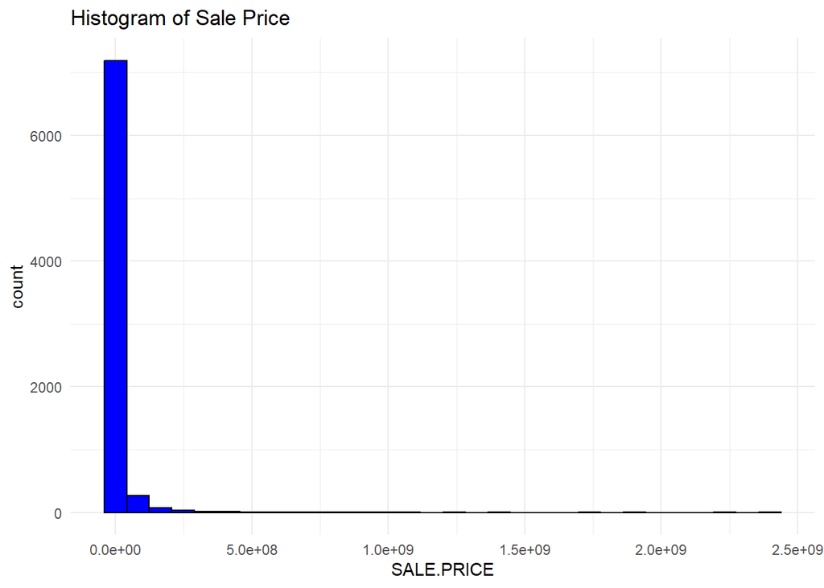

```r
# Distribution of SALE.PRICE: Histogram
ggplot(data_boro, aes(x = SALE.PRICE)) +
  geom_histogram(bins = 30, fill = "blue", color = "black") +
  ggtitle("Histogram of Sale Price") +
  theme_minimal()
```

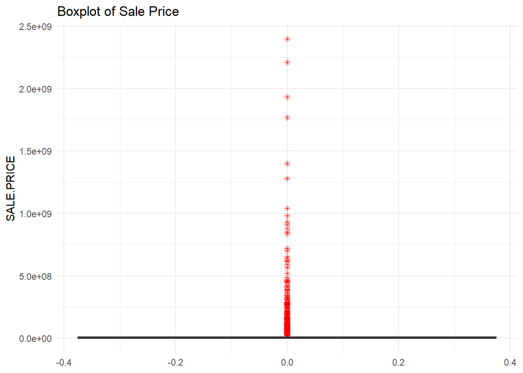

```r
# Boxplot of SALE.PRICE
ggplot(data_boro, aes(y = SALE.PRICE)) +
  geom_boxplot(fill = "lightblue", outlier.colour = "red", outlier.shape = 8) +
  ggtitle("Boxplot of Sale Price") +
  theme_minimal()
```

```r
# Identify outliers in SALE.PRICE using the IQR method
Q1 <- quantile(data_boro$SALE.PRICE, 0.25, na.rm = TRUE)
Q3 <- quantile(data_boro$SALE.PRICE, 0.75, na.rm = TRUE)
IQR_val <- Q3 - Q1
lower_bound <- Q1 - 1.5 * IQR_val
upper_bound <- Q3 + 1.5 * IQR_val

outliers <- data_boro %>%
  filter(SALE.PRICE < lower_bound | SALE.PRICE > upper_bound)

cat("Number of outlier observations for Sale Price:", nrow(outliers), "\n")
```

```
## Number of outlier observations for Sale Price: 785
```

```r
head(outliers)
```

```
##   BOROUGH NEIGHBORHOOD BUILDING.CLASS.CATEGORY TAX.CLASS.AS.OF.FINAL.ROLL BLOCK
## 1       1      CHELSEA     21 OFFICE BUILDINGS                          4   697
## 2       1      CHELSEA     21 OFFICE BUILDINGS                          4   697
## 3       1      CHELSEA     21 OFFICE BUILDINGS                          4   712
## 4       1      CHELSEA     21 OFFICE BUILDINGS                          4   802
## 5       1      CHELSEA     21 OFFICE BUILDINGS                          4   803
## 6       1      CHELSEA      22 STORE BUILDINGS                          4   697
##   LOT EASE.MENT BUILDING.CLASS.AS.OF.FINAL.ROLL              ADDRESS
## 1   5        NA                              O2 555 WEST 25TH STREET
## 2  23        NA                              O6 511 WEST 25TH STREET
## 3   1        NA                              O6        450 WEST 15TH
## 4  75        NA                              O6   158 WEST 27 STREET
## 5   4        NA                              O4         307 7 AVENUE
## 6  13        NA                              K9 521 WEST 25TH STREET
##   APARTMENT.NUMBER ZIP.CODE RESIDENTIAL.UNITS COMMERCIAL.UNITS TOTAL.UNITS
```

[output cut: 34 more lines]

```r
# Correlation Analysis
numeric_cols <- c("SALE.PRICE", "GROSS.SQUARE.FEET", "LAND.SQUARE.FEET")
data_cor <- data_boro[, numeric_cols]
data_cor <- na.omit(data_cor)
cor_matrix <- cor(data_cor, method = "pearson")
print(cor_matrix)
```

```
##                   SALE.PRICE GROSS.SQUARE.FEET LAND.SQUARE.FEET
## SALE.PRICE         1.0000000         0.4927886        0.1619058
## GROSS.SQUARE.FEET  0.4927886         1.0000000        0.5365858
## LAND.SQUARE.FEET   0.1619058         0.5365858        1.0000000
```

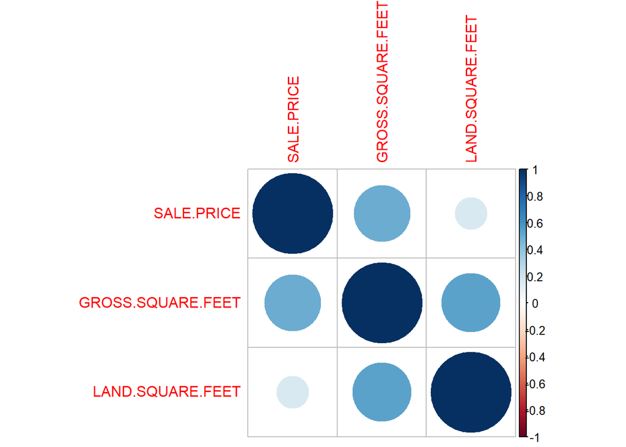

```r
corrplot(cor_matrix, method = "circle")
```

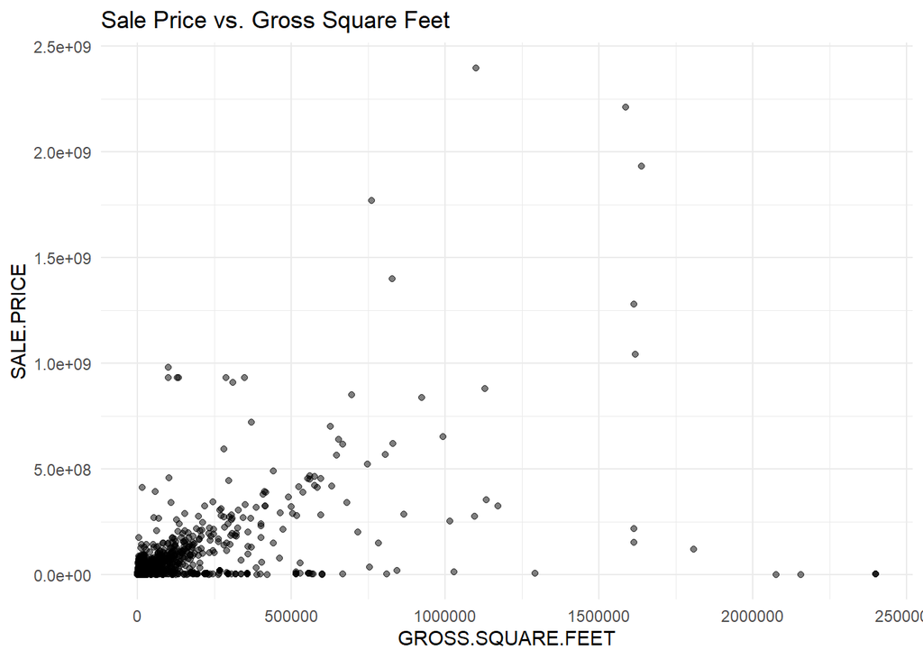

```r
# Scatter Plot for variables of interest
ggplot(data_boro, aes(x = GROSS.SQUARE.FEET, y = SALE.PRICE)) +
  geom_point(alpha = 0.5) +
  ggtitle("Sale Price vs. Gross Square Feet") +
  theme_minimal()
```

Based on the EDA results, the following steps were taken and observed:

1. The dataset was first filtered to include only the data points for the selected borough. The SALE.PRICE column was then cleaned to remove any values at 10 or below, and the GROSS.SQUARE.FEET and LAND.SQUARE.FEET columns underwent numeric conversion and removal of NA values, ensuring accuracy in subsequent analyses.
2. Summary statistics and the structure of the filtered dataset were examined. This provided an initial understanding of the central tendencies, spread, and potential anomalies in the data.
3. A histogram of the SALE.PRICE values was generated. This plot revealed the overall frequency distribution of home sale prices, highlighting where most transactions occurred and indicating any skewness in the data.
4. A boxplot of the SALE.PRICE was also created to provide a visual representation of the distribution and to clearly identify potential outlier values. By applying the IQR method, the boundaries for typical sale prices were determined, and observations that fell outside of these bounds were marked as outliers.
5. Additional plots, including scatter plots and a correlation matrix (using methods like corrplot), were produced. These visuals helped explore relationships between SALE.PRICE and other quantitative variables such as GROSS.SQUARE.FEET, lending insight into how different property attributes might influence the sale price.

This comprehensive exploratory analysis not only identified key trends within the dataset but also ensured that the subsequent modeling steps would be built on a well-understood and appropriately prepared dataset.

3. Regression Analysis to Predict Sale Price

```r
library(dplyr)
library(lubridate)
library(tidyverse)
library(caret)
# Data cleaning
data_boro$TOTAL.UNITS <- as.numeric(data_boro$TOTAL.UNITS)
data_boro <- data_boro %>% filter(!is.na(TOTAL.UNITS))
data_boro$YEAR.BUILT <- as.numeric(data_boro$YEAR.BUILT)
data_boro <- data_boro %>% filter(!is.na(YEAR.BUILT))
data_boro$BUILDING.CLASS.AT.TIME.OF.SALE <- as.factor(data_boro$BUILDING.CLASS.AT.TIME.OF.SALE)
data_boro$TAX.CLASS.AT.TIME.OF.SALE <- as.factor(data_boro$TAX.CLASS.AT.TIME.OF.SALE)


model1 <- lm(SALE.PRICE ~ GROSS.SQUARE.FEET + LAND.SQUARE.FEET + TOTAL.UNITS + YEAR.BUILT + BUILDING.CLASS.AT.TIME.OF.SALE + TAX.CLASS.AT.TIME.OF.SALE, data = data_boro)
summary(model1)
```

```
##
## Call:
## lm(formula = SALE.PRICE ~ GROSS.SQUARE.FEET + LAND.SQUARE.FEET +
##     TOTAL.UNITS + YEAR.BUILT + BUILDING.CLASS.AT.TIME.OF.SALE +
##     TAX.CLASS.AT.TIME.OF.SALE, data = data_boro)
##
## Residuals:
##        Min         1Q     Median         3Q        Max
## -913517026   -5375379   -1497970    1149671 1802665691
##
## Coefficients: (2 not defined because of singularities)
##                                    Estimate Std. Error t value Pr(>|t|)
## (Intercept)                      -1.586e+06  1.823e+07  -0.087  0.93068
## GROSS.SQUARE.FEET                 5.518e+02  1.211e+01  45.574  < 2e-16 ***
## LAND.SQUARE.FEET                  2.733e+01  5.125e+01   0.533  0.59379
## TOTAL.UNITS                      -3.068e+05  1.905e+04 -16.102  < 2e-16 ***
## YEAR.BUILT                        7.997e+02  1.898e+03   0.421  0.67353
## BUILDING.CLASS.AT.TIME.OF.SALEA4  7.892e+06  1.815e+07   0.435  0.66370
## BUILDING.CLASS.AT.TIME.OF.SALEA5  4.783e+06  1.969e+07   0.243  0.80809
## BUILDING.CLASS.AT.TIME.OF.SALEA7  1.691e+07  2.045e+07   0.827  0.40831
## BUILDING.CLASS.AT.TIME.OF.SALEA9  2.482e+06  1.874e+07   0.132  0.89464
## BUILDING.CLASS.AT.TIME.OF.SALEB1  3.769e+06  1.840e+07   0.205  0.83774
## BUILDING.CLASS.AT.TIME.OF.SALEB2  1.242e+06  2.169e+07   0.057  0.95436
## BUILDING.CLASS.AT.TIME.OF.SALEB3  3.490e+06  1.894e+07   0.184  0.85379
## BUILDING.CLASS.AT.TIME.OF.SALEB9  3.180e+06  1.876e+07   0.170  0.86540
## BUILDING.CLASS.AT.TIME.OF.SALEC0  3.272e+06  1.827e+07   0.179  0.85783
## BUILDING.CLASS.AT.TIME.OF.SALEC1  4.286e+06  1.807e+07   0.237  0.81248
## BUILDING.CLASS.AT.TIME.OF.SALEC2  4.501e+06  1.873e+07   0.240  0.81010
## BUILDING.CLASS.AT.TIME.OF.SALEC3  2.887e+06  1.841e+07   0.157  0.87537
## BUILDING.CLASS.AT.TIME.OF.SALEC4  6.036e+06  1.807e+07   0.334  0.73834
## BUILDING.CLASS.AT.TIME.OF.SALEC5  5.278e+06  1.814e+07   0.291  0.77110
## BUILDING.CLASS.AT.TIME.OF.SALEC6  3.442e+06  2.825e+07   0.122  0.90304
## BUILDING.CLASS.AT.TIME.OF.SALEC7  8.346e+06  1.801e+07   0.463  0.64308
## BUILDING.CLASS.AT.TIME.OF.SALEC9  3.005e+06  2.990e+07   0.101  0.91994
## BUILDING.CLASS.AT.TIME.OF.SALED1  4.438e+06  1.841e+07   0.241  0.80947
## BUILDING.CLASS.AT.TIME.OF.SALED2  8.511e+06  2.701e+07   0.315  0.75272
## BUILDING.CLASS.AT.TIME.OF.SALED3 -9.331e+06  1.896e+07  -0.492  0.62269
## BUILDING.CLASS.AT.TIME.OF.SALED4 -1.352e+08  2.183e+07  -6.195 6.12e-10 ***
## BUILDING.CLASS.AT.TIME.OF.SALED5  2.332e+07  2.076e+07   1.123  0.26130
## BUILDING.CLASS.AT.TIME.OF.SALED6  3.917e+07  1.907e+07   2.055  0.03996 *
```

[output cut: 94 more lines]

```
## BUILDING.CLASS.AT.TIME.OF.SALEW4  9.144e+07  5.652e+07   1.618  0.10573
## BUILDING.CLASS.AT.TIME.OF.SALEW7  1.670e+07  5.651e+07   0.295  0.76762
## BUILDING.CLASS.AT.TIME.OF.SALEW8  3.244e+07  3.576e+07   0.907  0.36435
## BUILDING.CLASS.AT.TIME.OF.SALEW9 -3.902e+07  5.653e+07  -0.690  0.49003
## BUILDING.CLASS.AT.TIME.OF.SALEZ4  2.014e+07  3.573e+07   0.564  0.57300
## BUILDING.CLASS.AT.TIME.OF.SALEZ5 -1.340e+09  5.197e+07 -25.794  < 2e-16 ***
## BUILDING.CLASS.AT.TIME.OF.SALEZ9  3.043e+07  3.573e+07   0.852  0.39448
## TAX.CLASS.AT.TIME.OF.SALE2               NA         NA      NA       NA
## TAX.CLASS.AT.TIME.OF.SALE4               NA         NA      NA       NA
## ---
## Signif. codes:  0 '***' 0.001 '**' 0.01 '*' 0.05 '.' 0.1 ' ' 1
##
## Residual standard error: 53600000 on 7495 degrees of freedom
## Multiple R-squared:  0.5032, Adjusted R-squared:  0.4947
## F-statistic:  59.3 on 128 and 7495 DF,  p-value: < 2.2e-16
```

```r
# Remove LAND.SQUARE.FEET and YEAR.BUILT to statisitcal insignificance and TAX.CLASS.AT.TIME.OF.SALE due to collinearity
model2 <- lm(SALE.PRICE ~ GROSS.SQUARE.FEET + TOTAL.UNITS + BUILDING.CLASS.AT.TIME.OF.SALE, data = data_boro)
summary(model2)
```

```
##
## Call:
## lm(formula = SALE.PRICE ~ GROSS.SQUARE.FEET + TOTAL.UNITS + BUILDING.CLASS.AT.TIME.OF.SALE,
##     data = data_boro)
##
## Residuals:
##        Min         1Q     Median         3Q        Max
## -914195087   -5373599   -1529427    1168073 1804561964
##
## Coefficients:
##                                    Estimate Std. Error t value Pr(>|t|)
## (Intercept)                       1.761e+04  1.787e+07   0.001  0.99921
## GROSS.SQUARE.FEET                 5.536e+02  1.161e+01  47.667  < 2e-16 ***
## TOTAL.UNITS                      -3.032e+05  1.789e+04 -16.950  < 2e-16 ***
## BUILDING.CLASS.AT.TIME.OF.SALEA4  7.847e+06  1.815e+07   0.432  0.66545
## BUILDING.CLASS.AT.TIME.OF.SALEA5  4.739e+06  1.969e+07   0.241  0.80979
## BUILDING.CLASS.AT.TIME.OF.SALEA7  1.689e+07  2.045e+07   0.826  0.40894
## BUILDING.CLASS.AT.TIME.OF.SALEA9  2.437e+06  1.874e+07   0.130  0.89651
## BUILDING.CLASS.AT.TIME.OF.SALEB1  3.727e+06  1.840e+07   0.203  0.83952
## BUILDING.CLASS.AT.TIME.OF.SALEB2  1.206e+06  2.169e+07   0.056  0.95566
## BUILDING.CLASS.AT.TIME.OF.SALEB3  3.443e+06  1.893e+07   0.182  0.85571
## BUILDING.CLASS.AT.TIME.OF.SALEB9  3.133e+06  1.876e+07   0.167  0.86736
## BUILDING.CLASS.AT.TIME.OF.SALEC0  3.233e+06  1.826e+07   0.177  0.85951
## BUILDING.CLASS.AT.TIME.OF.SALEC1  4.226e+06  1.806e+07   0.234  0.81501
## BUILDING.CLASS.AT.TIME.OF.SALEC2  4.450e+06  1.873e+07   0.238  0.81217
## BUILDING.CLASS.AT.TIME.OF.SALEC3  2.840e+06  1.840e+07   0.154  0.87737
## BUILDING.CLASS.AT.TIME.OF.SALEC4  5.963e+06  1.807e+07   0.330  0.74138
## BUILDING.CLASS.AT.TIME.OF.SALEC5  5.208e+06  1.814e+07   0.287  0.77400
## BUILDING.CLASS.AT.TIME.OF.SALEC6  3.560e+06  2.825e+07   0.126  0.89973
## BUILDING.CLASS.AT.TIME.OF.SALEC7  8.272e+06  1.801e+07   0.459  0.64599
## BUILDING.CLASS.AT.TIME.OF.SALEC9  2.951e+06  2.989e+07   0.099  0.92137
## BUILDING.CLASS.AT.TIME.OF.SALED1  4.408e+06  1.841e+07   0.239  0.81075
## BUILDING.CLASS.AT.TIME.OF.SALED2  8.437e+06  2.701e+07   0.312  0.75478
## BUILDING.CLASS.AT.TIME.OF.SALED3 -9.184e+06  1.896e+07  -0.484  0.62812
## BUILDING.CLASS.AT.TIME.OF.SALED4 -1.357e+08  2.181e+07  -6.219 5.27e-10 ***
## BUILDING.CLASS.AT.TIME.OF.SALED5  2.311e+07  2.075e+07   1.114  0.26532
## BUILDING.CLASS.AT.TIME.OF.SALED6  3.892e+07  1.906e+07   2.042  0.04114 *
## BUILDING.CLASS.AT.TIME.OF.SALED7  1.812e+07  1.852e+07   0.978  0.32797
## BUILDING.CLASS.AT.TIME.OF.SALED8 -7.896e+07  1.911e+07  -4.132 3.64e-05 ***
## BUILDING.CLASS.AT.TIME.OF.SALED9 -3.073e+06  1.919e+07  -0.160  0.87275
```

[output cut: 89 more lines]

```
## BUILDING.CLASS.AT.TIME.OF.SALEW1  6.013e+07  5.650e+07   1.064  0.28727
## BUILDING.CLASS.AT.TIME.OF.SALEW3 -1.795e+07  2.702e+07  -0.664  0.50649
## BUILDING.CLASS.AT.TIME.OF.SALEW4  9.200e+07  5.651e+07   1.628  0.10355
## BUILDING.CLASS.AT.TIME.OF.SALEW7  1.673e+07  5.650e+07   0.296  0.76717
## BUILDING.CLASS.AT.TIME.OF.SALEW8  3.246e+07  3.575e+07   0.908  0.36392
## BUILDING.CLASS.AT.TIME.OF.SALEW9 -3.815e+07  5.650e+07  -0.675  0.49960
## BUILDING.CLASS.AT.TIME.OF.SALEZ4  2.010e+07  3.573e+07   0.563  0.57372
## BUILDING.CLASS.AT.TIME.OF.SALEZ5 -1.327e+09  4.531e+07 -29.284  < 2e-16 ***
## BUILDING.CLASS.AT.TIME.OF.SALEZ9  3.045e+07  3.573e+07   0.852  0.39416
## ---
## Signif. codes:  0 '***' 0.001 '**' 0.01 '*' 0.05 '.' 0.1 ' ' 1
##
## Residual standard error: 53600000 on 7497 degrees of freedom
## Multiple R-squared:  0.5031, Adjusted R-squared:  0.4948
## F-statistic: 60.25 on 126 and 7497 DF,  p-value: < 2.2e-16
```

I began by converting TOTAL.UNITS and YEAR.BUILT to numeric and filtering out any rows that contained `NA` values for these crucial variables, ensuring clean numeric inputs. Next, I converted BOTH BUILDING.CLASS.AT.TIME.OF.SALE and TAX.CLASS.AT.TIME.OF.SALE into factors to properly account for their categorical nature in the model. I then tested multiple regression models, initially including LAND.SQUARE.FEET and YEAR.BUILT, but dropped them after finding them statistically insignificant (and TAX.CLASS.AT.TIME.OF.SALE due to collinearity). The simplified model (with GROSS.SQUARE.FEET, TOTAL.UNITS, and BUILDING.CLASS.AT.TIME.OF.SALE) achieved an R² of around 0.5032, which is comparable to the initial model’s performance but with fewer variables.

```r
library(dplyr)
library(caret)         # for data splitting, modeling, confusionMatrix
library(e1071)         # for Naive Bayes
library(class)         # for k-NN
library(randomForest)  # for Random Forest
set.seed(123)

data_boro$NEIGHBORHOOD <- as.factor(data_boro$NEIGHBORHOOD)

trainIndex <- createDataPartition(data_boro$NEIGHBORHOOD, p = 0.7, list = FALSE)
train_data <- data_boro[trainIndex, ]
test_data <- data_boro[-trainIndex, ]

# Naive Bayes
nb_model <- naiveBayes(NEIGHBORHOOD ~ SALE.PRICE + GROSS.SQUARE.FEET, data = train_data)
nb_pred <- predict(nb_model, newdata = test_data)

cat("=====Naive Bayes Results=====\n")
```

```
## =====Naive Bayes Results=====
```

```r
confusionMatrix(nb_pred, test_data$NEIGHBORHOOD)
```

```
## Confusion Matrix and Statistics
##
##                            Reference
## Prediction                  ALPHABET CITY CHELSEA CHINATOWN CIVIC CENTER
##   ALPHABET CITY                         0       0         0            0
##   CHELSEA                               0       0         0            0
##   CHINATOWN                            11      22        10            0
##   CIVIC CENTER                          0       0         0            0
##   CLINTON                               0       0         0            0
##   EAST VILLAGE                          2      12         4            6
##   FASHION                               0       0         0            0
##   FINANCIAL                             0       0         0            0
##   FLATIRON                              0       0         0            0
##   GRAMERCY                              0       0         0            0
##   GREENWICH VILLAGE-CENTRAL             0       0         0            0
##   GREENWICH VILLAGE-WEST                0       0         1            0
##   HARLEM-CENTRAL                        2       3         2            0
##   HARLEM-EAST                           0       0         0            0
##   HARLEM-UPPER                         14      39         9           11
##   HARLEM-WEST                           0       0         0            0
##   INWOOD                                0       0         0            0
##   JAVITS CENTER                         0       0         0            0
##   KIPS BAY                              0       0         0            0
##   LITTLE ITALY                          0       0         0            0
##   LOWER EAST SIDE                       0       0         0            0
##   MANHATTAN-UNKNOWN                     0       0         0            0
##   MANHATTAN VALLEY                      0       0         0            0
##   MIDTOWN CBD                           0       0         0            0
##   MIDTOWN EAST                          0       0         0            0
##   MIDTOWN WEST                          0       3         0            1
##   MORNINGSIDE HEIGHTS                   0       0         0            0
##   MURRAY HILL                           0       0         0            0
##   SOHO                                  0       0         0            0
##   SOUTHBRIDGE                           0       0         0            0
##   TRIBECA                               0       0         0            0
##   UPPER EAST SIDE (59-79)               0       1         0            0
##   UPPER EAST SIDE (79-96)               5       7         4            3
##   UPPER EAST SIDE (96-110)              0       0         0            0
##   UPPER WEST SIDE (59-79)               0       0         0            0
##   UPPER WEST SIDE (79-96)               0       0         0            0
```

[output cut: 674 more lines]

```
## Pos Pred Value                             0.0000000
## Neg Pred Value                             0.9730922
## Prevalence                                 0.0268959
## Detection Rate                             0.0000000
## Detection Prevalence                       0.0004409
## Balanced Accuracy                          0.4997734
##                      Class: WASHINGTON HEIGHTS UPPER
## Sensitivity                                  0.00000
## Specificity                                  1.00000
## Pos Pred Value                                   NaN
## Neg Pred Value                               0.98501
## Prevalence                                   0.01499
## Detection Rate                               0.00000
## Detection Prevalence                         0.00000
## Balanced Accuracy                            0.50000
```

```r
# k-NN
train_knn <- train_data %>% select(SALE.PRICE, GROSS.SQUARE.FEET)
test_knn <- test_data %>% select(SALE.PRICE, GROSS.SQUARE.FEET)

normalize <- function(x) {
  return((x - min(x)) / (max(x) - min(x)))
}

train_knn_norm <- as.data.frame(lapply(train_knn, normalize))
test_knn_norm <- as.data.frame(lapply(test_knn, normalize))

train_labels <- train_data$NEIGHBORHOOD
test_labels <- test_data$NEIGHBORHOOD

knn_pred <- knn(train = train_knn_norm,
                test = test_knn_norm,
                cl = train_labels,
                k = 5)

cat("=====kNN Results (k=5)=====\n")
```

```
## =====kNN Results (k=5)=====
```

```r
confusionMatrix(knn_pred, test_labels)
```

```
## Confusion Matrix and Statistics
##
##                            Reference
## Prediction                  ALPHABET CITY CHELSEA CHINATOWN CIVIC CENTER
##   ALPHABET CITY                         5       0         0            0
##   CHELSEA                               0       2         2            0
##   CHINATOWN                             0       0         0            0
##   CIVIC CENTER                          0       1         0            1
##   CLINTON                               0       0         1            0
##   EAST VILLAGE                          1       0         0            0
##   FASHION                               0       3         1            0
##   FINANCIAL                             0       0         0            0
##   FLATIRON                              0       0         1            1
##   GRAMERCY                              0       0         0            0
##   GREENWICH VILLAGE-CENTRAL             1       2         1            0
##   GREENWICH VILLAGE-WEST                2      30         5           11
##   HARLEM-CENTRAL                       11       5         0            0
##   HARLEM-EAST                           2       3         0            0
##   HARLEM-UPPER                          1       0         0            0
##   HARLEM-WEST                           0       0         0            0
##   INWOOD                                0       0         0            0
##   JAVITS CENTER                         0       0         0            0
##   KIPS BAY                              0       0         0            0
##   LITTLE ITALY                          0       0         0            0
##   LOWER EAST SIDE                       0       2         2            0
##   MANHATTAN-UNKNOWN                     0       0         0            0
##   MANHATTAN VALLEY                      0       0         1            0
##   MIDTOWN CBD                           1       2         1            0
##   MIDTOWN EAST                          0       2         2            0
##   MIDTOWN WEST                          0       5         2            1
##   MORNINGSIDE HEIGHTS                   0       0         0            0
##   MURRAY HILL                           0       2         1            0
##   SOHO                                  0       1         0            1
##   SOUTHBRIDGE                           0       0         0            0
##   TRIBECA                               0       0         1            0
##   UPPER EAST SIDE (59-79)               2      16         4            2
##   UPPER EAST SIDE (79-96)               5       5         5            0
##   UPPER EAST SIDE (96-110)              0       0         0            1
##   UPPER WEST SIDE (59-79)               1       3         0            0
##   UPPER WEST SIDE (79-96)               0       1         0            1
```

[output cut: 674 more lines]

```
## Pos Pred Value                              0.280000
## Neg Pred Value                              0.975925
## Prevalence                                  0.026896
## Detection Rate                              0.003086
## Detection Prevalence                        0.011023
## Balanced Accuracy                           0.553299
##                      Class: WASHINGTON HEIGHTS UPPER
## Sensitivity                                 0.088235
## Specificity                                 0.996419
## Pos Pred Value                              0.272727
## Neg Pred Value                              0.986265
## Prevalence                                  0.014991
## Detection Rate                              0.001323
## Detection Prevalence                        0.004850
## Balanced Accuracy                           0.542327
```

```r
# Random Forest
rf_model <- randomForest(NEIGHBORHOOD ~ SALE.PRICE + GROSS.SQUARE.FEET,
                         data = train_data,
                         ntree = 100,
                         mtry = 2,
                         importance = TRUE)
rf_pred <- predict(rf_model, newdata = test_data)

cat("=====Random Forest Results=====\n")
```

```
## =====Random Forest Results=====
```

```r
confusionMatrix(rf_pred, test_data$NEIGHBORHOOD)
```

```
## Confusion Matrix and Statistics
##
##                            Reference
## Prediction                  ALPHABET CITY CHELSEA CHINATOWN CIVIC CENTER
##   ALPHABET CITY                         8       2         1            3
##   CHELSEA                               0      10         1            0
##   CHINATOWN                             0       2         5            1
##   CIVIC CENTER                          0       0         1            3
##   CLINTON                               0       3         1            0
##   EAST VILLAGE                          1       3         0            1
##   FASHION                               0       1         0            0
##   FINANCIAL                             0       0         0            0
##   FLATIRON                              0       1         0            0
##   GRAMERCY                              1       1         1            1
##   GREENWICH VILLAGE-CENTRAL             0       4         0            0
##   GREENWICH VILLAGE-WEST                2       3         2            3
##   HARLEM-CENTRAL                        5       7         4            0
##   HARLEM-EAST                           1       0         0            0
##   HARLEM-UPPER                          0       0         1            1
##   HARLEM-WEST                           1       2         0            0
##   INWOOD                                0       0         0            1
##   JAVITS CENTER                         0       0         0            1
##   KIPS BAY                              2       2         0            0
##   LITTLE ITALY                          0       0         0            0
##   LOWER EAST SIDE                       1       4         3            2
##   MANHATTAN-UNKNOWN                     0       0         0            0
##   MANHATTAN VALLEY                      2       0         1            0
##   MIDTOWN CBD                           0       0         0            0
##   MIDTOWN EAST                          1       3         2            1
##   MIDTOWN WEST                          1       5         0            0
##   MORNINGSIDE HEIGHTS                   0       0         0            0
##   MURRAY HILL                           0       3         1            0
##   SOHO                                  1       1         0            0
##   SOUTHBRIDGE                           0       0         0            0
##   TRIBECA                               0       2         0            0
##   UPPER EAST SIDE (59-79)               2       8         1            2
##   UPPER EAST SIDE (79-96)               1      10         3            0
##   UPPER EAST SIDE (96-110)              0       0         0            0
##   UPPER WEST SIDE (59-79)               1       5         0            0
##   UPPER WEST SIDE (79-96)               1       2         0            0
```

[output cut: 674 more lines]

```
## Pos Pred Value                              0.238095
## Neg Pred Value                              0.979138
## Prevalence                                  0.026896
## Detection Rate                              0.006614
## Detection Prevalence                        0.027778
## Balanced Accuracy                           0.612076
##                      Class: WASHINGTON HEIGHTS UPPER
## Sensitivity                                 0.176471
## Specificity                                 0.987914
## Pos Pred Value                              0.181818
## Neg Pred Value                              0.987472
## Prevalence                                  0.014991
## Detection Rate                              0.002646
## Detection Prevalence                        0.014550
## Balanced Accuracy                           0.582192
```

The Naïve Bayes classifier yielded very low overall accuracy (around 4.7%) and poor sensitivity for most classes, suggesting that it struggles to distinguish among the diverse neighborhood categories based solely on the quantitative predictors. In contrast, the k-nearest neighbors (k-NN) classifier with k = 5 improved performance, achieving an accuracy of approximately 18.7% and slightly better sensitivity in some classes, though it still showed significant class imbalance. The Random Forest model outperformed both other approaches with an accuracy near 33.7% and a Kappa value of about 0.30, indicating a moderate level of agreement beyond chance; its ensemble approach appears better at capturing complex, nonlinear relationships in the data. Despite this improvement, all models displayed variability in sensitivity and specificity across different neighborhoods, which may be attributed to the high number of neighborhood levels and class imbalances. Overall, while the Random Forest classifier offers the best performance among the three methods, there remains room for further model refinement, such as grouping or rebalancing neighborhood categories, to achieve more consistent classification results.

```r
data <- read.csv("C:/Users/Shankar Veludandi/Google Drive/ITWS_6600/A5/NYC_Citywide_Annualized_Calendar_Sales_Update_20241107.csv")

data_boro2 <- subset(data, BOROUGH == "2")

summary(data_boro2)
```

```
##    BOROUGH          NEIGHBORHOOD       BUILDING.CLASS.CATEGORY
##  Length:38219       Length:38219       Length:38219
##  Class :character   Class :character   Class :character
##  Mode  :character   Mode  :character   Mode  :character
##
##
##
##
##  TAX.CLASS.AS.OF.FINAL.ROLL     BLOCK           LOT         EASE.MENT
##  Length:38219               Min.   :2260   Min.   :   1.0   Mode:logical
##  Class :character           1st Qu.:3302   1st Qu.:  22.0   NA's:38219
##  Mode  :character           Median :4128   Median :  48.0
##                             Mean   :4200   Mean   : 295.1
##                             3rd Qu.:5037   3rd Qu.: 117.0
##                             Max.   :5958   Max.   :9100.0
##
##  BUILDING.CLASS.AS.OF.FINAL.ROLL   ADDRESS          APARTMENT.NUMBER
##  Length:38219                    Length:38219       Length:38219
##  Class :character                Class :character   Class :character
##  Mode  :character                Mode  :character   Mode  :character
##
##
##
##
##     ZIP.CODE     RESIDENTIAL.UNITS COMMERCIAL.UNITS   TOTAL.UNITS
##  Min.   :    0   Min.   :  0.000   Min.   :  0.000   Min.   :  0.000
##  1st Qu.:10461   1st Qu.:  1.000   1st Qu.:  0.000   1st Qu.:  1.000
##  Median :10465   Median :  2.000   Median :  0.000   Median :  2.000
##  Mean   :10406   Mean   :  3.192   Mean   :  0.288   Mean   :  3.474
##  3rd Qu.:10469   3rd Qu.:  2.000   3rd Qu.:  0.000   3rd Qu.:  2.000
##  Max.   :10803   Max.   :948.000   Max.   :252.000   Max.   :955.000
##  NA's   :1       NA's   :2960      NA's   :3458      NA's   :2913
##  LAND.SQUARE.FEET   GROSS.SQUARE.FEET    YEAR.BUILT   TAX.CLASS.AT.TIME.OF.SALE
##  Length:38219       Length:38219       Min.   :   0   Min.   :1.000
##  Class :character   Class :character   1st Qu.:1920   1st Qu.:1.000
##  Mode  :character   Mode  :character   Median :1935   Median :1.000
##                                        Mean   :1817   Mean   :1.517
##                                        3rd Qu.:1960   3rd Qu.:2.000
##                                        Max.   :2022   Max.   :4.000
##                                        NA's   :1322
```

[output cut: 17 more lines]

```
##  Min.   :    2   Min.   :2000000   Min.   :2.023e+09   Length:38219
##  1st Qu.:  162   1st Qu.:2021744   1st Qu.:2.033e+09   Class :character
##  Median :  324   Median :2061715   Median :2.041e+09   Mode  :character
##  Mean   : 6087   Mean   :2058036   Mean   :2.042e+09
##  3rd Qu.:  444   3rd Qu.:2086273   3rd Qu.:2.050e+09
##  Max.   :46202   Max.   :2211972   Max.   :2.060e+09
##  NA's   :8602    NA's   :1753      NA's   :1753
##  Census.Tract.2020   NTA.Code
##  Min.   :    2     Length:38219
##  1st Qu.:  204     Class :character
##  Median :  348     Mode  :character
##  Mean   : 8140
##  3rd Qu.:11502
##  Max.   :51601
##  NA's   :31198
```

```r
str(data_boro2)
```

```
## 'data.frame':    38219 obs. of  31 variables:
##  $ BOROUGH                        : chr  "2" "2" "2" "2" ...
##  $ NEIGHBORHOOD                   : chr  "BATHGATE" "BATHGATE" "BATHGATE" "BATHGATE" ...
##  $ BUILDING.CLASS.CATEGORY        : chr  "01 ONE FAMILY DWELLINGS" "01 ONE FAMILY DWELLINGS" "01 ONE FAMILY DWELLINGS" "01 ONE FAMILY DWELLINGS" ...
##  $ TAX.CLASS.AS.OF.FINAL.ROLL     : chr  "1" "1" "1" "1" ...
##  $ BLOCK                          : int  2905 3028 3030 3037 3039 3039 3046 3050 3050 3053 ...
##  $ LOT                            : int  26 24 65 101 29 63 38 80 80 102 ...
##  $ EASE.MENT                      : logi  NA NA NA NA NA NA ...
##  $ BUILDING.CLASS.AS.OF.FINAL.ROLL: chr  "A9" "A1" "A1" "S0" ...
##  $ ADDRESS                        : chr  "1667 WASHINGTON AVENUE" "410 EAST 179TH STREET" "4455 PARK AVENUE" "443 EAST 180 STREET" ...
##  $ APARTMENT.NUMBER               : chr  "" "" "" "" ...
##  $ ZIP.CODE                       : int  10457 10457 10457 10457 10458 10458 10457 10457 10457 10458 ...
##  $ RESIDENTIAL.UNITS              : int  1 1 1 1 1 1 1 1 1 1 ...
##  $ COMMERCIAL.UNITS               : int  0 0 0 2 0 0 0 0 0 0 ...
##  $ TOTAL.UNITS                    : int  1 1 1 3 1 1 1 1 1 1 ...
```

[output cut: 17 more lines]

```r
data_boro2 <- data_boro2 %>% filter(SALE.PRICE > 10)
data_boro2$GROSS.SQUARE.FEET <- as.numeric(gsub(",", "", data_boro2$GROSS.SQUARE.FEET))
data_boro2 <- data_boro2 %>% filter(!is.na(GROSS.SQUARE.FEET) & GROSS.SQUARE.FEET > 0)
data_boro2$TOTAL.UNITS <- as.numeric(data_boro2$TOTAL.UNITS)
data_boro2 <- data_boro2 %>% filter(!is.na(TOTAL.UNITS))
data_boro2$BUILDING.CLASS.AT.TIME.OF.SALE <- as.factor(data_boro2$BUILDING.CLASS.AT.TIME.OF.SALE)

model <- lm(SALE.PRICE ~ GROSS.SQUARE.FEET + TOTAL.UNITS + BUILDING.CLASS.AT.TIME.OF.SALE, data = data_boro2)
summary(model2)
```

```
##
## Call:
## lm(formula = SALE.PRICE ~ GROSS.SQUARE.FEET + TOTAL.UNITS + BUILDING.CLASS.AT.TIME.OF.SALE,
##     data = data_boro)
##
## Residuals:
##        Min         1Q     Median         3Q        Max
## -914195087   -5373599   -1529427    1168073 1804561964
##
## Coefficients:
##                                    Estimate Std. Error t value Pr(>|t|)
## (Intercept)                       1.761e+04  1.787e+07   0.001  0.99921
## GROSS.SQUARE.FEET                 5.536e+02  1.161e+01  47.667  < 2e-16 ***
## TOTAL.UNITS                      -3.032e+05  1.789e+04 -16.950  < 2e-16 ***
## BUILDING.CLASS.AT.TIME.OF.SALEA4  7.847e+06  1.815e+07   0.432  0.66545
## BUILDING.CLASS.AT.TIME.OF.SALEA5  4.739e+06  1.969e+07   0.241  0.80979
## BUILDING.CLASS.AT.TIME.OF.SALEA7  1.689e+07  2.045e+07   0.826  0.40894
## BUILDING.CLASS.AT.TIME.OF.SALEA9  2.437e+06  1.874e+07   0.130  0.89651
## BUILDING.CLASS.AT.TIME.OF.SALEB1  3.727e+06  1.840e+07   0.203  0.83952
## BUILDING.CLASS.AT.TIME.OF.SALEB2  1.206e+06  2.169e+07   0.056  0.95566
## BUILDING.CLASS.AT.TIME.OF.SALEB3  3.443e+06  1.893e+07   0.182  0.85571
## BUILDING.CLASS.AT.TIME.OF.SALEB9  3.133e+06  1.876e+07   0.167  0.86736
## BUILDING.CLASS.AT.TIME.OF.SALEC0  3.233e+06  1.826e+07   0.177  0.85951
## BUILDING.CLASS.AT.TIME.OF.SALEC1  4.226e+06  1.806e+07   0.234  0.81501
## BUILDING.CLASS.AT.TIME.OF.SALEC2  4.450e+06  1.873e+07   0.238  0.81217
## BUILDING.CLASS.AT.TIME.OF.SALEC3  2.840e+06  1.840e+07   0.154  0.87737
## BUILDING.CLASS.AT.TIME.OF.SALEC4  5.963e+06  1.807e+07   0.330  0.74138
## BUILDING.CLASS.AT.TIME.OF.SALEC5  5.208e+06  1.814e+07   0.287  0.77400
## BUILDING.CLASS.AT.TIME.OF.SALEC6  3.560e+06  2.825e+07   0.126  0.89973
## BUILDING.CLASS.AT.TIME.OF.SALEC7  8.272e+06  1.801e+07   0.459  0.64599
## BUILDING.CLASS.AT.TIME.OF.SALEC9  2.951e+06  2.989e+07   0.099  0.92137
## BUILDING.CLASS.AT.TIME.OF.SALED1  4.408e+06  1.841e+07   0.239  0.81075
## BUILDING.CLASS.AT.TIME.OF.SALED2  8.437e+06  2.701e+07   0.312  0.75478
## BUILDING.CLASS.AT.TIME.OF.SALED3 -9.184e+06  1.896e+07  -0.484  0.62812
## BUILDING.CLASS.AT.TIME.OF.SALED4 -1.357e+08  2.181e+07  -6.219 5.27e-10 ***
## BUILDING.CLASS.AT.TIME.OF.SALED5  2.311e+07  2.075e+07   1.114  0.26532
## BUILDING.CLASS.AT.TIME.OF.SALED6  3.892e+07  1.906e+07   2.042  0.04114 *
## BUILDING.CLASS.AT.TIME.OF.SALED7  1.812e+07  1.852e+07   0.978  0.32797
## BUILDING.CLASS.AT.TIME.OF.SALED8 -7.896e+07  1.911e+07  -4.132 3.64e-05 ***
## BUILDING.CLASS.AT.TIME.OF.SALED9 -3.073e+06  1.919e+07  -0.160  0.87275
```

[output cut: 89 more lines]

```
## BUILDING.CLASS.AT.TIME.OF.SALEW1  6.013e+07  5.650e+07   1.064  0.28727
## BUILDING.CLASS.AT.TIME.OF.SALEW3 -1.795e+07  2.702e+07  -0.664  0.50649
## BUILDING.CLASS.AT.TIME.OF.SALEW4  9.200e+07  5.651e+07   1.628  0.10355
## BUILDING.CLASS.AT.TIME.OF.SALEW7  1.673e+07  5.650e+07   0.296  0.76717
## BUILDING.CLASS.AT.TIME.OF.SALEW8  3.246e+07  3.575e+07   0.908  0.36392
## BUILDING.CLASS.AT.TIME.OF.SALEW9 -3.815e+07  5.650e+07  -0.675  0.49960
## BUILDING.CLASS.AT.TIME.OF.SALEZ4  2.010e+07  3.573e+07   0.563  0.57372
## BUILDING.CLASS.AT.TIME.OF.SALEZ5 -1.327e+09  4.531e+07 -29.284  < 2e-16 ***
## BUILDING.CLASS.AT.TIME.OF.SALEZ9  3.045e+07  3.573e+07   0.852  0.39416
## ---
## Signif. codes:  0 '***' 0.001 '**' 0.01 '*' 0.05 '.' 0.1 ' ' 1
##
## Residual standard error: 53600000 on 7497 degrees of freedom
## Multiple R-squared:  0.5031, Adjusted R-squared:  0.4948
## F-statistic: 60.25 on 126 and 7497 DF,  p-value: < 2.2e-16
```

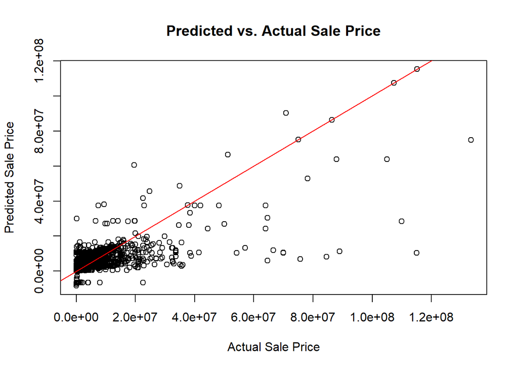

```r
predictions <- predict(model, newdata = data_boro2)
residuals <- data_boro2$SALE.PRICE - predictions

plot(data_boro2$SALE.PRICE, predictions,
     xlab = "Actual Sale Price",
     ylab = "Predicted Sale Price",
     main = "Predicted vs. Actual Sale Price")
abline(0, 1, col="red")
```

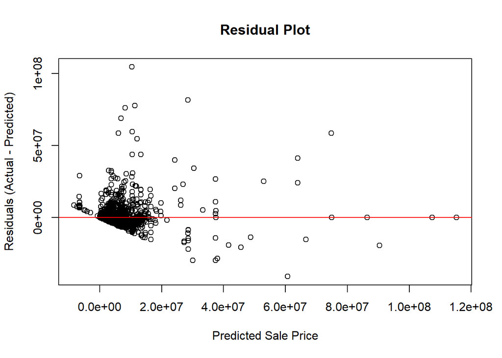

```r
plot(predictions, residuals,
     xlab = "Predicted Sale Price",
     ylab = "Residuals (Actual - Predicted)",
     main = "Residual Plot")
abline(h = 0, col = "red")
```

```r
set.seed(123)

data_boro2$NEIGHBORHOOD <- as.factor(data_boro2$NEIGHBORHOOD)

trainIndex <- createDataPartition(data_boro2$NEIGHBORHOOD, p = 0.7, list = FALSE)
train_data <- data_boro2[trainIndex, ]
test_data <- data_boro2[-trainIndex, ]

# Naive Bayes
nb_model <- naiveBayes(NEIGHBORHOOD ~ SALE.PRICE + GROSS.SQUARE.FEET, data = train_data)
nb_pred <- predict(nb_model, newdata = test_data)

cat("=====Naive Bayes Results=====\n")
```

```
## =====Naive Bayes Results=====
```

```r
confusionMatrix(nb_pred, test_data$NEIGHBORHOOD)
```

```
## Confusion Matrix and Statistics
##
##                            Reference
## Prediction                  BATHGATE BAYCHESTER BEDFORD PARK/NORWOOD BELMONT
##   BATHGATE                         0          0                    0       0
##   BAYCHESTER                       1          0                    1       1
##   BEDFORD PARK/NORWOOD             0          0                    9       1
##   BELMONT                          0          0                    0       0
##   BRONX-UNKNOWN                    0          0                    0       0
##   BRONX PARK                       0          0                    0       0
##   BRONXDALE                        2          2                    1       0
##   CASTLE HILL/UNIONPORT            0          0                    3       0
##   CITY ISLAND                      0          0                    1       0
##   CITY ISLAND-PELHAM STRIP         0          0                    0       0
##   CO-OP CITY                       0          0                    0       0
##   COUNTRY CLUB                    43        346                   68      39
##   CROTONA PARK                     0          0                    0       0
##   EAST RIVER                       0          0                    0       0
##   EAST TREMONT                     0          0                    0       0
##   FIELDSTON                        0          0                    0       0
##   FORDHAM                          0          0                    0       0
##   HIGHBRIDGE/MORRIS HEIGHTS        0          0                    0       0
##   HUNTS POINT                      0          0                    1       0
##   KINGSBRIDGE HTS/UNIV HTS         0          0                    0       0
##   KINGSBRIDGE/JEROME PARK          0          0                    0       0
##   MELROSE/CONCOURSE                0          0                    3       0
##   MORRIS PARK/VAN NEST            10         81                   35      15
##   MORRISANIA/LONGWOOD              5          3                    5       5
##   MOTT HAVEN/PORT MORRIS           0          0                    0       1
##   MOUNT HOPE/MOUNT EDEN            0          0                    0       0
##   PARKCHESTER                      0          0                    0       0
##   PELHAM GARDENS                   0          0                    0       0
##   PELHAM PARKWAY NORTH             0          0                    0       0
##   PELHAM PARKWAY SOUTH             0          0                    0       0
##   RIVERDALE                        0          0                    1       0
##   SCHUYLERVILLE/PELHAM BAY         0          0                    0       0
##   SOUNDVIEW                        5          1                    7       3
##   THROGS NECK                      0          0                    0       0
##   VAN CORTLANDT PARK               0          0                    0       0
##   WAKEFIELD                        0          0                    0       0
```

[output cut: 697 more lines]

```
## Pos Pred Value                              NA              NaN
## Neg Pred Value                              NA          0.95161
## Prevalence                                   0          0.04839
## Detection Rate                               0          0.00000
## Detection Prevalence                         0          0.00000
## Balanced Accuracy                           NA          0.50000
##                      Class: WESTCHESTER Class: WILLIAMSBRIDGE Class: WOODLAWN
## Sensitivity                     0.00000              0.030769         0.00000
## Specificity                     1.00000              0.948810         1.00000
## Pos Pred Value                      NaN              0.051852             NaN
## Neg Pred Value                  0.97507              0.914963         0.98827
## Prevalence                      0.02493              0.083394         0.01173
## Detection Rate                  0.00000              0.002566         0.00000
## Detection Prevalence            0.00000              0.049487         0.00000
## Balanced Accuracy               0.50000              0.489790         0.50000
```

```r
# k-NN
train_knn <- train_data %>% select(SALE.PRICE, GROSS.SQUARE.FEET)
test_knn <- test_data %>% select(SALE.PRICE, GROSS.SQUARE.FEET)

normalize <- function(x) {
  return((x - min(x)) / (max(x) - min(x)))
}

train_knn_norm <- as.data.frame(lapply(train_knn, normalize))
test_knn_norm <- as.data.frame(lapply(test_knn, normalize))

train_labels <- train_data$NEIGHBORHOOD
test_labels <- test_data$NEIGHBORHOOD

knn_pred <- knn(train = train_knn_norm,
                test = test_knn_norm,
                cl = train_labels,
                k = 5)

cat("=====kNN Results (k=5)=====\n")
```

```
## =====kNN Results (k=5)=====
```

```r
confusionMatrix(knn_pred, test_labels)
```

```
## Confusion Matrix and Statistics
##
##                            Reference
## Prediction                  BATHGATE BAYCHESTER BEDFORD PARK/NORWOOD BELMONT
##   BATHGATE                         2          6                    1       0
##   BAYCHESTER                      11         62                   11       4
##   BEDFORD PARK/NORWOOD             1         11                   13       0
##   BELMONT                          1          2                    1       0
##   BRONX-UNKNOWN                    0          0                    0       0
##   BRONX PARK                       0          0                    0       0
##   BRONXDALE                        2         29                    4       2
##   CASTLE HILL/UNIONPORT            0         10                    5       1
##   CITY ISLAND                      0          3                    2       0
##   CITY ISLAND-PELHAM STRIP         0          0                    0       0
##   CO-OP CITY                       0          0                    0       0
##   COUNTRY CLUB                     1         12                    1       1
##   CROTONA PARK                     0          5                    1       1
##   EAST RIVER                       0          0                    0       0
##   EAST TREMONT                     2          7                    4       1
##   FIELDSTON                        0          0                    0       0
##   FORDHAM                          0          1                    4       2
##   HIGHBRIDGE/MORRIS HEIGHTS        1          5                    3       2
##   HUNTS POINT                      3          3                    2       1
##   KINGSBRIDGE HTS/UNIV HTS         3          4                    3       3
##   KINGSBRIDGE/JEROME PARK          0          3                    1       1
##   MELROSE/CONCOURSE                3          7                    7       2
##   MORRIS PARK/VAN NEST             2         11                    1       3
##   MORRISANIA/LONGWOOD              3         14                   12      11
##   MOTT HAVEN/PORT MORRIS           4          5                    3       3
##   MOUNT HOPE/MOUNT EDEN            0          3                    6       0
##   PARKCHESTER                      0         11                    3       2
##   PELHAM GARDENS                   1          6                    0       2
##   PELHAM PARKWAY NORTH             2         19                    2       0
##   PELHAM PARKWAY SOUTH             1          3                    0       1
##   RIVERDALE                        2          1                    5       2
##   SCHUYLERVILLE/PELHAM BAY         1         16                    4       3
##   SOUNDVIEW                       13         53                   10       7
##   THROGS NECK                      2         35                   11       4
##   VAN CORTLANDT PARK               0          0                    0       0
##   WAKEFIELD                        1         23                    6       2
```

[output cut: 697 more lines]

```
## Pos Pred Value                              NA         0.075000
## Neg Pred Value                              NA         0.953053
## Prevalence                                   0         0.048387
## Detection Rate                               0         0.003849
## Detection Prevalence                         0         0.051320
## Balanced Accuracy                           NA         0.514831
##                      Class: WESTCHESTER Class: WILLIAMSBRIDGE Class: WOODLAWN
## Sensitivity                   0.0294118               0.15604        0.000000
## Specificity                   0.9813910               0.89422        0.991840
## Pos Pred Value                0.0388350               0.11833        0.000000
## Neg Pred Value                0.9753409               0.92092        0.988174
## Prevalence                    0.0249267               0.08339        0.011730
## Detection Rate                0.0007331               0.01301        0.000000
## Detection Prevalence          0.0188783               0.10997        0.008065
## Balanced Accuracy             0.5054014               0.52513        0.495920
```

```r
# Random Forest
rf_model <- randomForest(NEIGHBORHOOD ~ SALE.PRICE + GROSS.SQUARE.FEET,
                         data = train_data,
                         ntree = 100,
                         mtry = 2,
                         importance = TRUE)
rf_pred <- predict(rf_model, newdata = test_data)

cat("=====Random Forest Results=====\n")
```

```
## =====Random Forest Results=====
```

```r
confusionMatrix(rf_pred, test_data$NEIGHBORHOOD)
```

```
## Confusion Matrix and Statistics
##
##                            Reference
## Prediction                  BATHGATE BAYCHESTER BEDFORD PARK/NORWOOD BELMONT
##   BATHGATE                         6          7                    3       1
##   BAYCHESTER                       3         81                    5       5
##   BEDFORD PARK/NORWOOD             3          7                   12       1
##   BELMONT                          0          4                    3       7
##   BRONX-UNKNOWN                    0          0                    0       0
##   BRONX PARK                       0          0                    0       1
##   BRONXDALE                        6         27                    7       6
##   CASTLE HILL/UNIONPORT            1         16                    3       0
##   CITY ISLAND                      1          5                    1       0
##   CITY ISLAND-PELHAM STRIP         0          0                    0       0
##   CO-OP CITY                       0          0                    0       0
##   COUNTRY CLUB                     1         10                    4       2
##   CROTONA PARK                     0          2                    2       1
##   EAST RIVER                       0          0                    0       0
##   EAST TREMONT                     1          6                    2       2
##   FIELDSTON                        0          1                    0       2
##   FORDHAM                          0          2                    4       0
##   HIGHBRIDGE/MORRIS HEIGHTS        2          6                    8       0
##   HUNTS POINT                      0          2                    2       2
##   KINGSBRIDGE HTS/UNIV HTS         0          6                    5       0
##   KINGSBRIDGE/JEROME PARK          0          4                    2       2
##   MELROSE/CONCOURSE                4          8                    3       0
##   MORRIS PARK/VAN NEST             1         17                    8       2
##   MORRISANIA/LONGWOOD              6         15                    9       6
##   MOTT HAVEN/PORT MORRIS           5          7                    5       3
##   MOUNT HOPE/MOUNT EDEN            0          1                    3       1
##   PARKCHESTER                      0          7                    5       3
##   PELHAM GARDENS                   1          3                    0       0
##   PELHAM PARKWAY NORTH             1         16                    1       2
##   PELHAM PARKWAY SOUTH             0          5                    4       1
##   RIVERDALE                        2          8                    5       3
##   SCHUYLERVILLE/PELHAM BAY         3         16                    5       2
##   SOUNDVIEW                       11         39                   10       5
##   THROGS NECK                      4         37                    4       3
##   VAN CORTLANDT PARK               0          0                    0       0
##   WAKEFIELD                        4         20                    8       0
```

[output cut: 697 more lines]

```
## Pos Pred Value                              NA         0.122271
## Neg Pred Value                              NA         0.954850
## Prevalence                           0.0000000         0.048387
## Detection Rate                       0.0000000         0.005132
## Detection Prevalence                 0.0001833         0.041972
## Balanced Accuracy                           NA         0.533674
##                      Class: WESTCHESTER Class: WILLIAMSBRIDGE Class: WOODLAWN
## Sensitivity                    0.088235               0.16264       0.0781250
## Specificity                    0.979323               0.92821       0.9918398
## Pos Pred Value                 0.098361               0.17090       0.1020408
## Neg Pred Value                 0.976753               0.92415       0.9890882
## Prevalence                     0.024927               0.08339       0.0117302
## Detection Rate                 0.002199               0.01356       0.0009164
## Detection Prevalence           0.022361               0.07936       0.0089809
## Balanced Accuracy              0.533779               0.54543       0.5349824
```

Based on my results, the Naïve Bayes and k-NN classifiers performed similarly across both datasets, with overall accuracies around 4–5% and approximately 18–19%, respectively. However, while the Random Forest model yielded a robust accuracy of about 33.7% (with a Kappa value of ~0.30) on the original borough dataset, its performance dropped considerably to roughly 15.9% (with a Kappa of ~0.12) on the new dataset. This discrepancy indicates that although the simpler models generalize consistently, the Random Forest model—which appears to capture complex, nonlinear patterns in the original data—may be overfitted to that specific borough’s characteristics. The reduced performance on the new dataset suggests there are differences in the underlying distribution of predictors (such as property size, total units, or building class) or neighborhood compositions that the Random Forest model did not fully capture. Overall, this comparison demonstrates that while some aspects of the model generalize well, further refinement or adjustment (e.g., through rebalancing or grouping neighborhood categories) may be necessary for the Random Forest classifier to perform robustly across different boroughs.

Overall, the study shows that while linear models capture the primary drivers of sale price—such as gross square footage and total units—they still leave considerable unexplained variation, particularly in capturing the finer nuances across different neighborhoods. The Random Forest model, although generally performing better than simpler methods like Naïve Bayes and k-NN, still struggles with class imbalances and the high number of neighborhood categories. Regression and classification results indicate that issues with data quality, such as missing values and skewed distributions, combined with the inherent complexity of multiple building classes and neighborhoods, limit the reliability of the models. The notable drop in accuracy when applying the models to the second borough dataset suggests that the models do not generalize seamlessly beyond the training context, hinting at potential overfitting or unmodeled variations in local housing dynamics. To improve the results, future work could focus on grouping or rebalancing neighborhood categories, refining model parameters, or incorporating additional predictors (for example, building age or location-based scores) to more effectively capture the unique patterns present in each borough.